# AshleysherryKombarakranAntonyBabu-9015649-Section-2Practicallab-2

## Practical Lab 2: Multivariate Linear Regression, Non-Parametric Models and Cross-Validation

- Name - Ashley Shery Komabarakaran Antony Babu
- Section - 2
- Student ID - 9015649

### Part 1:

### 1. Getting the data

```python
from sklearn import datasets
diabetes_data = datasets.load_diabetes(as_frame=True)  # load as a DataFrame for easier exploration
X, y = diabetes_data.data, diabetes_data.target
```

### 2. Frame the Problem:

Goal: We want to predict the dependent variable y, representing "disease progression one year after baseline" as a function of the features in X.

Physician Screening Tool: Designed to help identify those patients who are at risk of decline due to their diabetes.

### 3. EDA (Exploratory Data Analysis):

- Statistics:

```python
X.describe()
y.describe()
```

```
count    442.000000
mean     152.133484
std       77.093005
min       25.000000
25%       87.000000
50%      140.500000
75%      211.500000
max      346.000000
Name: target, dtype: float64
```

Insights from Basic Statistics:

- The describe() function provides key statistics for each feature in terms of mean, standard deviation, min, max, and the quartiles.
- Observe features that have large variances or possible outliers that may call for attention at the pre-processing stage.
- Look at the range of values across the features; this might be where some need scaling before training on the model.
- Scatter plots

  Plot relationships between feature and targets

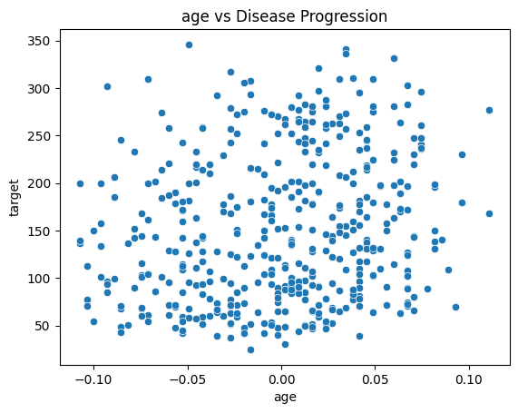

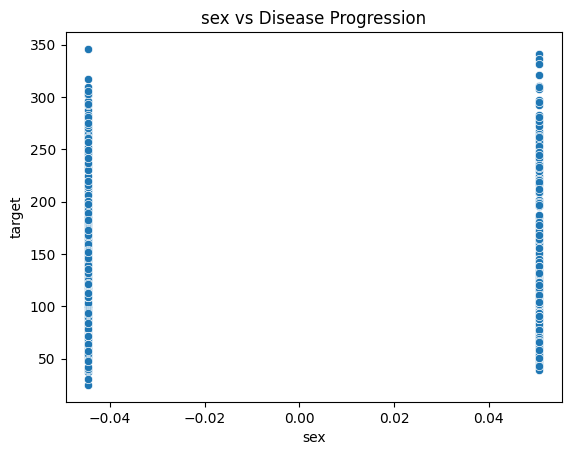

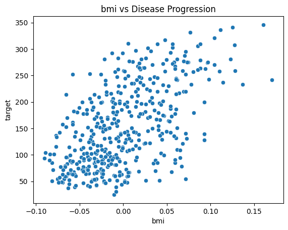

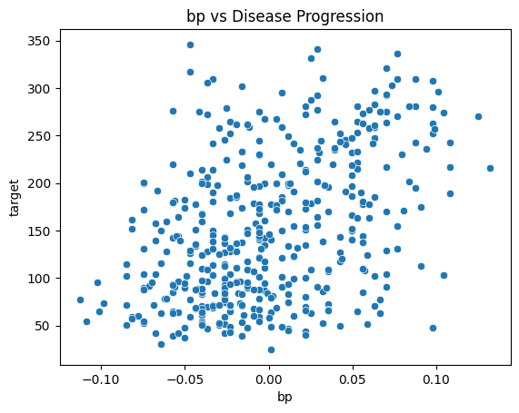

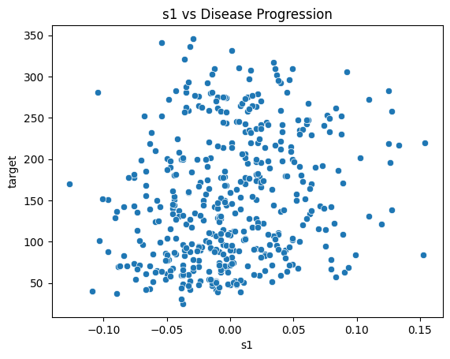

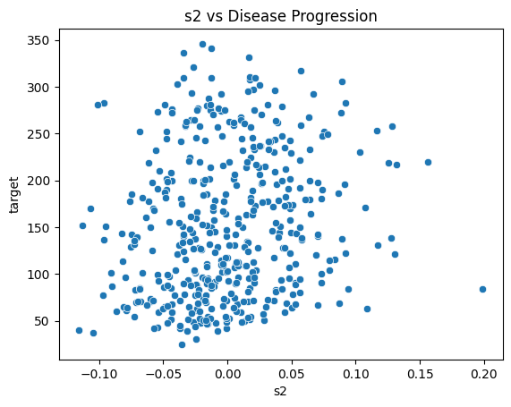

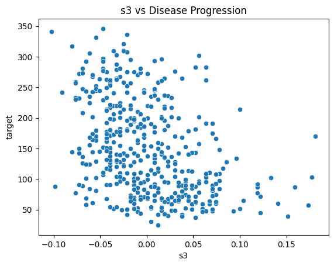

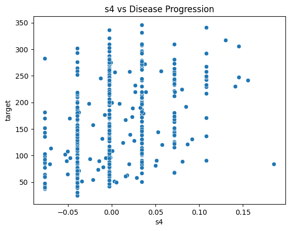

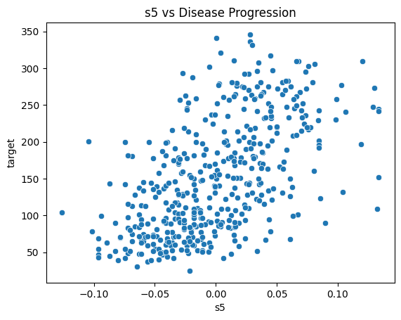

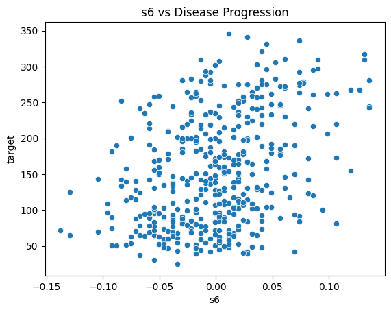

```python
import seaborn as sns
import matplotlib.pyplot as plt

for col in X.columns:
    sns.scatterplot(x=X[col], y=y)
    plt.title(f'{col} vs Disease Progression')
    plt.show()
```

Insights from Scatter Plots:

- Linear or nonlinear trends: Any pattern or relationship that can be observed between the features and the target variable.
- Other features such as BMI, bp might exhibit a whole-some trend and might act as a better predictor regarding the progression of the disease.
- The features for which no trend is fairly obvious may not give anything to the model and hence can be reconsidered for exclusion at later stages.
- Histogram